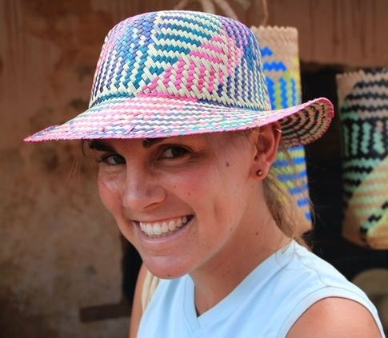

A Bay Area Native, I grew up in beautiful Sonoma County, CA and graduated from Stanford University with a B.S. degree in [Earth Systems](https://pangea.stanford.edu/esys) in 2010. Post-graduation, I spent two years working a variety of science and development-related jobs, first as a [communications intern with World Wildlife Fund in Madagascar](http://wwf.panda.org/how_you_can_help/volunteer/volunteer/volunteer_stories/madagascar/vondrozo_forest/cara_brook/), then as field coordinator for a Smithsonian Institution project focused on emerging rodent-borne diseases in Laikipia, Kenya. I rounded out my “time off” with a short-term stint as a GIS analyst for [Peninsula Open Space Trust](https://openspacetrust.org/) and an eight-month gig as a research technician on the [USGS Minnesota Wolf Project](http://www.davemech.org/volunteering.html). In the fall of 2012, I moved to New Jersey to embark on a PhD in the [Department of Ecology and Evolutionary Biology at Princeton University](https://eeb.princeton.edu/) and began chasing bat viruses across Madagascar. In August 2017, I defended my dissertation and moved to Berkeley, California to begin my postdoctoral fellowship with the [Miller Institute](http://miller.berkeley.edu/about). I am conducting my research jointly in the labs of [Professor Mike Boots](https://bootslab.org/) and [Professor Britt Glaunsinger](http://glaunsingerlab.berkeley.edu/) in the Departments of Integrative Biology and Plant and Microbiology. When I’m not doing science, you’ll find me running or hiking throughout the North American West.  
*(photo credit: Christa Szumski)*  
Full CV